# Proteomics Final Project

```python
negative = matches[matches['RFpnScore']<-0.9] #greater than -0.9 consider positive for interaction
```

```python
negative
```

|  | #geneID1 | geneSym1 | geneID2 | geneSym2 | RFpnScore | hprdLabel | Unnamed: 6 | GeneID1:Synonyms:description | Unnamed: 8 | 27features | Unnamed: 10 | GDBID | GeneticDisorder | match |
| --- | --- | --- | --- | --- | --- | --- | --- | --- | --- | --- | --- | --- | --- | --- |
| 19976 | 7098 | TLR3 | 5956 | OPN1LW | -0.900888 | 2 | NaN | 7098:-:toll-like receptor 3 | NaN | 1,1,2,2,0.3780,0.0056,0.0276,0.0233,0.0315,0.0... | NaN | NaN | NaN | Y |
| 19977 | 7099 | TLR4 | 221391 | OPN5 | -0.906325 | 2 | NaN | 7099:TOLL\|hToll:toll-like receptor 4 | NaN | 1 1 2 2 0.3780 0.0056 0.0276 0.0233 0.0315 0.2... | NaN | NaN | NaN | Y |
| 19977 | 7099 | TLR4 | 5956 | OPN1LW | -0.908256 | 2 | NaN | 7099:TOLL\|hToll:toll-like receptor 4 | NaN | 1,1,2,2,0.3780,0.0056,0.0276,0.0233,0.0315,0.0... | NaN | NaN | NaN | Y |
| 18899 | 6351 | CCL4 | 2652 | OPN1MW | -0.914048 | 2 | NaN | 6351:ACT2\|AT744.1\|G-26\|LAG1\|MGC104418\|MGC12602... | NaN | 0,0,2,1.5,0.3780,0.0056,0.0276,0.0028638978907... | NaN | NaN | NaN | Y |
| 7068 | 2833 | CXCR3 | 5956 | OPN1LW | -0.915524 | 2 | NaN | 2833:CD183\|CKR-L2\|CMKAR3\|GPR9\|IP10\|IP10-R\|Mig-... | NaN | 1,1,2,1,0.3780,0.0056,0.0276,0.0233,0.0315,0.0... | NaN | NaN | NaN | Y |
| ... | ... | ... | ... | ... | ... | ... | ... | ... | ... | ... | ... | ... | ... | ... |
| 19976 | 7098 | TLR3 | 221391 | OPN5 | -1.004208 | 2 | NaN | 7098:-:toll-like receptor 3 | NaN | 1 1 2 2 0.3780 0.0056 0.0276 0.0233 0.0315 -0.... | NaN | NaN | NaN | Y |
| 15585 | 51284 | TLR7 | 5956 | OPN1LW | -1.004222 | 2 | NaN | 51284:-:toll-like receptor 7 | NaN | 1,0,1,0.5,0.3780,0.0056,0.0276,0.0233,0.0315,0... | NaN | NaN | NaN | Y |
| 19974 | 7096 | TLR1 | 221391 | OPN5 | -1.004240 | 2 | NaN | 7096:DKFZp547I0610\|DKFZp564I0682\|KIAA0012\|MGC1... | NaN | 1 0 2 2 0.3780 0.0056 0.0276 0.0233 0.0315 0.0... | NaN | NaN | NaN | Y |
| 15584 | 51284 | TLR7 | 10692 | RRH | -1.005062 | 2 | NaN | 51284:-:toll-like receptor 7 | NaN | 1 0 1 1.5 0.3780 0.0056 0.0276 -0.129531770173... | NaN | NaN | NaN | Y |
| 9400 | 3569 | IL6 | 5956 | OPN1LW | -1.005228 | 2 | NaN | 3569:BSF2\|HGF\|HSF\|IFNB2\|IL-6:interleukin 6 (in... | NaN | 0,0,2,2,0.3780,0.0056,0.0276,0.0233,0.0315,0.0... | NaN | NaN | NaN | Y |

75 rows × 14 columns

```python
positive = matches[matches['RFpnScore']>-0.9]
```

```python
positive
```

[output not shown]

117 rows × 14 columns

```python
len(positive)/len(matches) #ratio of the positive and the all possible combination found from the data
```

```
0.609375
```

```python
# venn = positive
```

```python
RRH = positive[positive['geneSym2']=="RRH"]['geneSym1']
```

```python
RHO = positive[positive['geneSym2']=="RHO"]['geneSym1']
RGR = positive[positive['geneSym2']=="RGR"]['geneSym1']
```

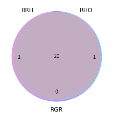

```python
import matplotlib.pyplot as plt
from matplotlib_venn import venn2, venn3

set1 = set(RRH)
set2 = set(RHO)
set3 = set(RGR)

venn3([set1, set2, set3], ('RRH', 'RHO',"RGR"))

plt.show()
```

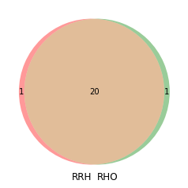

```python
venn2([set1, set2], ('RRH', 'RHO'))
plt.show()
```

```python
set(RHO) & set(RRH) & set(RGR)
```

```
{'CCL2',
 'CCL3',
 'CCL4',
 'CCR1',
 'CCR2',
 'CCR3',
 'CCR4',
 'CXCL10',
 'CXCL9',
 'CXCR3',
 'IFNG',
 'IFNGR1',
 'IL6',
 'TLR1',
 'TLR2',
 'TLR3',
 'TLR4',
 'TLR6',
 'TLR8',
 'TNF'}
```

```python
set(RHO) - set(RRH)
```

```
{'TLR5'}
```

```python
set(RRH) - set(RHO)
```

```
{'IL6R'}
```

There is some evidence suggesting a functional connection between rhodopsin and the immune system, although the exact mechanisms and significance of this connection are not yet fully understood. Here are a few points highlighting the potential functional significance of the link between rhodopsin and the immune system:

Microglia activation: Microglia are the immune cells of the central nervous system, including the retina. Rhodopsin has been reported to play a role in activating microglia in the retina, which could contribute to neuroinflammation and degenerative processes in retinal diseases like age-related macular degeneration (AMD) and retinitis pigmentosa (RP).

Inflammatory response: Rhodopsin has been suggested to influence the release of pro-inflammatory cytokines and chemokines, which can affect the immune response in the eye. In certain conditions, such as retinal degeneration, the dysregulation of inflammatory processes might contribute to disease progression.

Autoimmunity: Autoantibodies targeting rhodopsin have been identified in some patients with autoimmune retinopathy (AIR), a rare disorder causing progressive vision loss due to the immune system attacking retinal proteins. This suggests a potential connection between rhodopsin and immune-mediated retinal damage.

Retinal degeneration and Alzheimer's disease: Some studies have found a link between retinal degeneration (e.g., due to rhodopsin mutations) and Alzheimer's disease, which is characterized by neuroinflammation and immune system dysfunction. While the precise relationship between rhodopsin, immune system, and Alzheimer's disease is not yet clear, it highlights the possibility of a functional connection between these factors.

Despite these findings, more research is needed to fully understand the functional significance of the connection between rhodopsin and the immune system. Further studies could help uncover the molecular mechanisms underlying this link and its implications for the development of novel diagnostic or therapeutic strategies for retinal and immune-related disorders.

There is evidence suggesting a connection between rhodopsin, Alzheimer's disease, and the immune system. Rhodopsin, a light-sensitive G protein-coupled receptor (GPCR) in the retina, has been reported to be altered in Alzheimer's disease patients, possibly due to the deposition of amyloid-beta (Aβ) in the retina. The immune system is also implicated in Alzheimer's disease, as neuroinflammation and immune responses to Aβ and other misfolded proteins are thought to contribute to the disease progression.

One study that investigated the potential link between rhodopsin and Alzheimer's disease.This study found that Aβ deposits are present in the retinas of Alzheimer's disease patients and are correlated with the disease severity. Furthermore, they demonstrated that noninvasive retinal imaging could be used to detect these deposits as a potential biomarker for Alzheimer's disease.

Although the study does not directly investigate the role of the immune system, it does establish a connection between rhodopsin and Alzheimer's disease. The immune system's involvement in Alzheimer's disease, particularly through neuroinflammation, could potentially influence the observed alterations in rhodopsin and the retina. Further studies would be required to elucidate the exact functional significance and mechanistic details of the connection between rhodopsin, Alzheimer's disease, and the immune system.

reference:

Koronyo, Y., Biggs, D., Barron, E., Boyer, D. S., Pearlman, J. A., Au, W. J., ... & Black, K. L. (2017). Retinal amyloid pathology and proof-of-concept imaging trial in Alzheimer's disease. JCI Insight, 2(16), e93621. DOI: 10.1172/jci.insight.93621